# MQT7015 - Travail pratique 1 |

Équipe 1

Elsy Tiffanie Akpene Aboh 111 180 502

Elhadji Abdou Aziz Sall 111 225 484

Loïc Artino 536 756 361

12 mars 2021

# Instructions

Remettez **deux fichiers R notebook (.Rmd et .html correspondants) avec les codes R et les résultats commentés**. Ces fichiers doivent être construits en remplissant ce fichier-ci. Les solutions des éxercices des séances vous donnent une idée de la quantité et de la typologie des commentaires requis. Écrivez tout le code de manière qu’on puisse l’exécuter à nouveau en obtenant les mêmes résultats.

# Introduction et description des données

Nous voulons performer une analyse de la structure du capital des compagnies, inspirée par [Baker & Wurgler (2002)](https://doi.org/10.1111/1540-6261.00414). Pour ce faire, nous étudions plusieurs variables explicatives potentielles pouvant avoir un impact sur le levier financier des entreprises (le ratio de dettes/actifs) avant et après une introduction en bourse (IPO; Initial Public Offering).

Les informations contenues dans le fichier de données `FirmIPO.csv` proviennent des bases de données de Compustat et de CRSP. Notez que certaines valeurs sont manquantes. Voici les variables et ce qu’elles représentent:

- `gvkey`: identifiant de la firme
- `IPOfyear`: variable catégorielle reliée aux années fiscales
  - `IPOfyear=0` indique la première année fiscale après l’IPO où les valeurs aux marchés apparaissent dans Compustat
  - `IPOfyear=1` deuxième année fiscale avec des données
  - `IPOfyear=2` troisième année fiscale…
  - etc.
- `BL`: levier financier comptable (Book Leverage; ratio de dettes/actifs), calculé à partir de valeurs comptables et en pourcentages
- `ML`: levier financier au marché (Market Leverage; ratio de dettes/actifs), calculé à partir de valeurs aux marchés et en pourcentages
- `lagMB`: ratio valeur au marché/valeur aux livres (market-to-book), une année auparavant
- `lagTang`: ratio de tangibilité des actifs (asset tangibility; immobilisations corporelles/actifs), une année auparavant
- `lagProf`: ratio de profitabilité (revenus/actifs), une année auparavant
- `lagSize`: taille de la firme en échelle logarithmique, une année auparavant
- `lagMBefwa`: similaire au ratio market-to-book, avec une “moyenne pondérée par le financement externe” et ce, une année auparavant
  - Cette variable est définie par l’eq (3) dans [Baker & Wurgler (2002)](https://doi.org/10.1111/1540-6261.00414). C’est une forme particulière de moyenne pondérée, sur les valeurs passées de ratios market-to-book et qui prend en compte le financement externe

Pour chacune des paires de firme (`gvkey`) et d’année fiscale (`IPOfyear`), l’échantillon contient 12 lignes. Chacune de ces lignes correspond à un mois de l’année fiscale de la firme.

*Note*: le terme *lag* implique un décalage. Pour cet ensemble de données, le lag est d’une année.

# But de l’analyse

Le but de l’analyse est de prédire le levier financier au marché (variable `ML`) en utilisant les variables décalées (`lagMBefwa`, `lagMB`, `lagTang`, `lagProf` et `lagSize`), pour des sous-échantillons identifiés par le même année fiscale. En particulier, on veut établir le rôle de la nouvelle variable `lagMBefwa` dans le modèle. Notez que la variable `lagMBefwa` n’est pas disponible pour l’année fiscale `IPOfyear=1`.

# Tâches à faire:

## Tâche 1. (6 points)

Le levier financier comptable et le levier financier au marché sont à fréquence mensuelle, alors que les autres variables sont constantes pendant toute l’année fiscale. Il faut donc commencer par transformer les valeurs de levier financier comptable et de levier financier au marché en valeurs annuelles en prenant leur moyenne pour chaqune des paires de firme et d’année fiscale. Faites attention aux valeurs manquantes. Utilisez la fonction `aggregate` de R avec les arguments suivants: `FUN='mean'`, `na.rm=TRUE`, `na.action=NULL` (utilisez la fonction `help` pour savoir la syntaxe et la signification de chaque entrée!).

Après cette transformation, la taille de l’ensemble de données devrait être d’environ 1/12 de celle d’origine. Vérifiez-le.

Pourquoi est-il important, dans ce cas-ci, d’agréger les différents mois d’une année fiscale pour chaque firme avant d’implémenter un modèle de régression (sur un sous-échantillon identifié par le même année fiscale)? Quelle hypothèse du modèle de régression linéaire n’est pas respectée sinon? Expliquez.

```r
# Utilisation du tidyverse pour la manipulation des données
library(tidyverse)

# On importe les données dans un dataframe et on affiche les premières lignes

firm_ipo = read.csv("TP1/FirmIPO.csv", header = TRUE, sep = ";")
head(firm_ipo)

# On vérifie les données
str(firm_ipo)
summary(firm_ipo)

# On agrège les données

firm_agg = aggregate(firm_ipo, by = list(firm_ipo$gvkey, firm_ipo$IPOfyear), FUN = 'mean', na.action = NULL, na.rm = TRUE)

# On ne garde pas les colonnes Group.1, Group.2, gvkey et BL, non significatives pour l'analyse

firm_agg = firm_agg[,-c(1:3,5)]
head(firm_agg)

# On a effectivement environ 1/12 des données d'origine :
nrow(firm_agg) / nrow(firm_ipo)
```

Voici les données importées brutes :

| gvkey | IPOfyear | BL | ML | lagMBefwa | lagMB | lagTang | lagProf | lagSize |
| --- | --- | --- | --- | --- | --- | --- | --- | --- |
| 12994 | 0 | 42.51756 | NA | NA | NA | NA | NA | NA |
| 12994 | 0 | 42.51756 | NA | NA | NA | NA | NA | NA |
| 12994 | 0 | 42.51756 | NA | NA | NA | NA | NA | NA |
| 12994 | 0 | 42.51756 | 45.17200 | NA | NA | NA | NA | NA |
| 12994 | 0 | 42.51756 | 44.22119 | NA | NA | NA | NA | NA |
| 12994 | 0 | 42.51756 | 42.86773 | NA | NA | NA | NA | NA |

Nous vérifions par la suite l’état global du jeu de données :

```r
summary(firm_ipo)
```

```
     gvkey           IPOfyear            BL               ML
 Min.   :  1001   Min.   : 0.000   Min.   :  0.98   Min.   : 0.19
 1st Qu.: 10010   1st Qu.: 1.000   1st Qu.: 25.30   1st Qu.:12.18
 Median : 14994   Median : 2.000   Median : 41.91   Median :27.70
 Mean   : 24028   Mean   : 2.996   Mean   : 43.22   Mean   :33.41
 3rd Qu.: 29114   3rd Qu.: 5.000   3rd Qu.: 59.14   3rd Qu.:50.27
 Max.   :223007   Max.   :10.000   Max.   :100.00   Max.   :99.97
                                   NA's   :3930     NA's   :36650
   lagMBefwa         lagMB          lagTang         lagProf
 Min.   :0.00    Min.   : 0.07   Min.   : 0.00   Min.   :-140.56
 1st Qu.:0.00    1st Qu.: 1.01   1st Qu.:11.72   1st Qu.:   7.85
 Median :0.59    Median : 1.44   Median :24.11   Median :  13.76
 Mean   :1.51    Mean   : 1.93   Mean   :30.60   Mean   :  12.64
 3rd Qu.:2.40    3rd Qu.: 2.31   3rd Qu.:44.79   3rd Qu.:  19.67
 Max.   :9.99    Max.   :10.00   Max.   :99.98   Max.   : 115.81
 NA's   :55194   NA's   :84044   NA's   :55303   NA's   :55726
    lagSize
 Min.   :-5.52
 1st Qu.: 3.65
 Median : 4.54
 Mean   : 4.59
 3rd Qu.: 5.50
 Max.   :10.71
 NA's   :55500
```

```r
str(firm_ipo)
```

```
'data.frame':   264476 obs. of  9 variables:
 $ gvkey    : int  12994 12994 12994 12994 12994 12994 12994 12994 12994 12994 ...
 $ IPOfyear : int  0 0 0 0 0 0 0 0 0 0 ...
 $ BL       : num  42.5 42.5 42.5 42.5 42.5 ...
 $ ML       : num  NA NA NA 45.2 44.2 ...
 $ lagMBefwa: num  NA NA NA NA NA NA NA NA NA NA ...
 $ lagMB    : num  NA NA NA NA NA NA NA NA NA NA ...
 $ lagTang  : num  NA NA NA NA NA NA NA NA NA NA ...
 $ lagProf  : num  NA NA NA NA NA NA NA NA NA NA ...
 $ lagSize  : num  NA NA NA NA NA NA NA NA NA NA ...
```

La variable `gvkey` de même que `BL` ne sont pas pertinentes pour l’analyse des données car `gvkey` est un identifiant. Nous les enlèverons par la suite. Toutes les données sont de type numérique, seuls l’année fiscale et l’identifiant sont du type entier. Enfin, il y a beaucoup de données manquantes, au nombre de **346347**.

Nous devons agréger les données mensuelles afin d’obtenir une moyenne annuelle car sinon, l’hypothèse d’indépendance des erreurs n’est pas respectée. En effet, les données représentant des séries temporelles, les observations mensuelles d’une même année fiscale peuvent être correlées entre elles. Ainsi, on aurait : $cov(\epsilon_i,\epsilon_j) ≠ 0, ~\forall~~i≠j$

Également, nous prenons soin de ne pas considérer les valeurs manquantes dans le calcul des moyennes pour les variables, grâce à l’argument `na.rm = TRUE` de la fonction `aggregate()`.

Voici après agrégation :

| IPOfyear | ML | lagMBefwa | lagMB | lagTang | lagProf | lagSize |
| --- | --- | --- | --- | --- | --- | --- |
| 0 | NaN | NaN | NaN | NaN | NaN | NaN |
| 0 | 58.142277 | NaN | NaN | NaN | NaN | NaN |
| 0 | 61.394371 | NaN | NaN | NaN | NaN | NaN |
| 0 | 76.266284 | NaN | NaN | NaN | NaN | NaN |
| 0 | 2.778768 | NaN | NaN | NaN | NaN | NaN |
| 0 | NaN | NaN | NaN | NaN | NaN | NaN |

Nous obtenons effectivement un sous-ensemble égal à **0.0894599**, soit environ 1/12 des données d’origine. Néanmoins, l’agrégation a généré de nombreuses valeurs manquantes que nous allons supprimer dans le cadre de l’analyse.

## Tâche 2. (3 points)

Supprimez les observations qui contiennent des données manquantes de l’ensemble de données, en utilisant la fonction `na.omit`. Combien d’observations reste-t-il en total? Combien d’observations y a-t-il dans chaque sous-échantillon identifié par chaque année fiscale?

```r
# Suppression des NA et vérification du nombre d'observations

firm_agg1 = na.omit(firm_agg)
nrow(firm_agg1)

# On compile le nombre d'observations de chaque sous-échantillon dans un seul tableau récapitulatif

nb_obs = firm_agg1 %>%
  group_by(IPOfyear) %>%
  summarise('Nombre d\'observations' = n())
```

Après avoir utilisé la fonction `na.omit`, il ne reste plus que **16322** observations. Le tableau ci-dessous présente leur nombre, par année fiscale :

| IPOfyear | Nombre d’observations |
| --- | --- |
| 1 | 3312 |
| 2 | 3059 |
| 3 | 2502 |
| 4 | 1928 |
| 5 | 1517 |
| 6 | 1203 |
| 7 | 936 |
| 8 | 737 |
| 9 | 614 |
| 10 | 514 |

## Tâche 3. (5 points)

Pour chaque valeur d’année fiscale `IPOfyear=1,3,5,10`, calculez et affichez le sommaire statistique du levier financier au marché. Puis, créez quatre boîtes à moustaches de cette variable dans les années fiscales `IPOfyear=1,3,5,10`. Utilisez la même limite pour l’axe y, afin de pouvoir les comparer facilement.

Suivant une IPO, est-ce que le levier financier au marché est constant à travers le temps? Si non, comment changent-il?

**Sommaire statistique pour `IPOfyear = 1`**

```r
# Afficher les sommaires statistiques

firm_agg1 %>%
  filter(IPOfyear == 1) %>%
  summary()
```

```
    IPOfyear       ML            lagMBefwa     lagMB           lagTang
 Min.   :1   Min.   : 0.6151   Min.   :0   Min.   :0.1842   Min.   : 0.000
 1st Qu.:1   1st Qu.:11.5573   1st Qu.:0   1st Qu.:1.1641   1st Qu.: 7.873
 Median :1   Median :25.9542   Median :0   Median :1.7533   Median :17.658
 Mean   :1   Mean   :32.1531   Mean   :0   Mean   :2.2988   Mean   :25.691
 3rd Qu.:1   3rd Qu.:48.8761   3rd Qu.:0   3rd Qu.:2.8625   3rd Qu.:38.023
 Max.   :1   Max.   :99.4612   Max.   :0   Max.   :9.9983   Max.   :95.643
    lagProf          lagSize
 Min.   :-77.52   Min.   :-5.521
 1st Qu.:  7.92   1st Qu.: 3.211
 Median : 14.25   Median : 4.061
 Mean   : 12.89   Mean   : 4.103
 3rd Qu.: 20.33   3rd Qu.: 5.020
 Max.   :105.18   Max.   :10.621
```

**Sommaire statistique pour `IPOfyear = 3`**

```r
firm_agg1 %>%
  filter(IPOfyear == 3) %>%
  summary(.)
```

```
    IPOfyear       ML            lagMBefwa          lagMB          lagTang
 Min.   :3   Min.   : 0.8619   Min.   :0.0000   Min.   :0.163   Min.   : 0.00
 1st Qu.:3   1st Qu.:14.5385   1st Qu.:0.8766   1st Qu.:1.001   1st Qu.:11.36
 Median :3   Median :30.6981   Median :1.2638   Median :1.415   Median :22.16
 Mean   :3   Mean   :35.9293   Mean   :1.6306   Mean   :1.932   Mean   :29.91
 3rd Qu.:3   3rd Qu.:53.9028   3rd Qu.:2.0542   3rd Qu.:2.334   3rd Qu.:43.90
 Max.   :3   Max.   :99.2523   Max.   :9.8827   Max.   :9.883   Max.   :97.32
    lagProf            lagSize
 Min.   :-124.777   Min.   :-3.912
 1st Qu.:   6.432   1st Qu.: 3.760
 Median :  12.851   Median : 4.599
 Mean   :  10.950   Mean   : 4.634
 3rd Qu.:  19.001   3rd Qu.: 5.508
 Max.   :  78.796   Max.   :10.643
```

**Sommaire statistique pour `IPOfyear = 5`**

```r
firm_agg1 %>%
  filter(IPOfyear == 5) %>%
  summary(.)
```

```
    IPOfyear       ML            lagMBefwa         lagMB
 Min.   :5   Min.   : 0.3844   Min.   :0.000   Min.   :0.06785
 1st Qu.:5   1st Qu.:16.9281   1st Qu.:1.575   1st Qu.:0.95043
 Median :5   Median :33.3949   Median :2.636   Median :1.27111
 Mean   :5   Mean   :38.3001   Mean   :3.041   Mean   :1.66661
 3rd Qu.:5   3rd Qu.:56.7250   3rd Qu.:4.139   3rd Qu.:1.96171
 Max.   :5   Max.   :98.3495   Max.   :9.989   Max.   :8.50489
    lagTang         lagProf           lagSize
 Min.   : 0.00   Min.   :-92.250   Min.   :-1.981
 1st Qu.:13.15   1st Qu.:  7.643   1st Qu.: 4.126
 Median :26.04   Median : 12.938   Median : 4.997
 Mean   :32.05   Mean   : 12.144   Mean   : 5.040
 3rd Qu.:47.39   3rd Qu.: 18.689   3rd Qu.: 5.900
 Max.   :98.33   Max.   :112.825   Max.   :10.656
```

**Sommaire statistique pour `IPOfyear = 10`**

```r
firm_agg1 %>%
  filter(IPOfyear == 10) %>%
  summary(.)
```

```
    IPOfyear        ML           lagMBefwa         lagMB
 Min.   :10   Min.   : 3.444   Min.   :0.000   Min.   :0.3755
 1st Qu.:10   1st Qu.:19.760   1st Qu.:2.257   1st Qu.:0.9622
 Median :10   Median :35.138   Median :3.764   Median :1.2853
 Mean   :10   Mean   :38.363   Mean   :4.011   Mean   :1.6180
 3rd Qu.:10   3rd Qu.:54.480   3rd Qu.:5.554   3rd Qu.:1.9019
 Max.   :10   Max.   :99.000   Max.   :9.887   Max.   :8.9066
    lagTang          lagProf           lagSize
 Min.   : 0.269   Min.   :-66.644   Min.   :2.046
 1st Qu.:17.804   1st Qu.:  8.747   1st Qu.:4.470
 Median :29.721   Median : 13.684   Median :5.464
 Mean   :35.490   Mean   : 13.644   Mean   :5.471
 3rd Qu.:49.604   3rd Qu.: 18.863   3rd Qu.:6.358
 Max.   :98.951   Max.   :107.247   Max.   :9.922
```

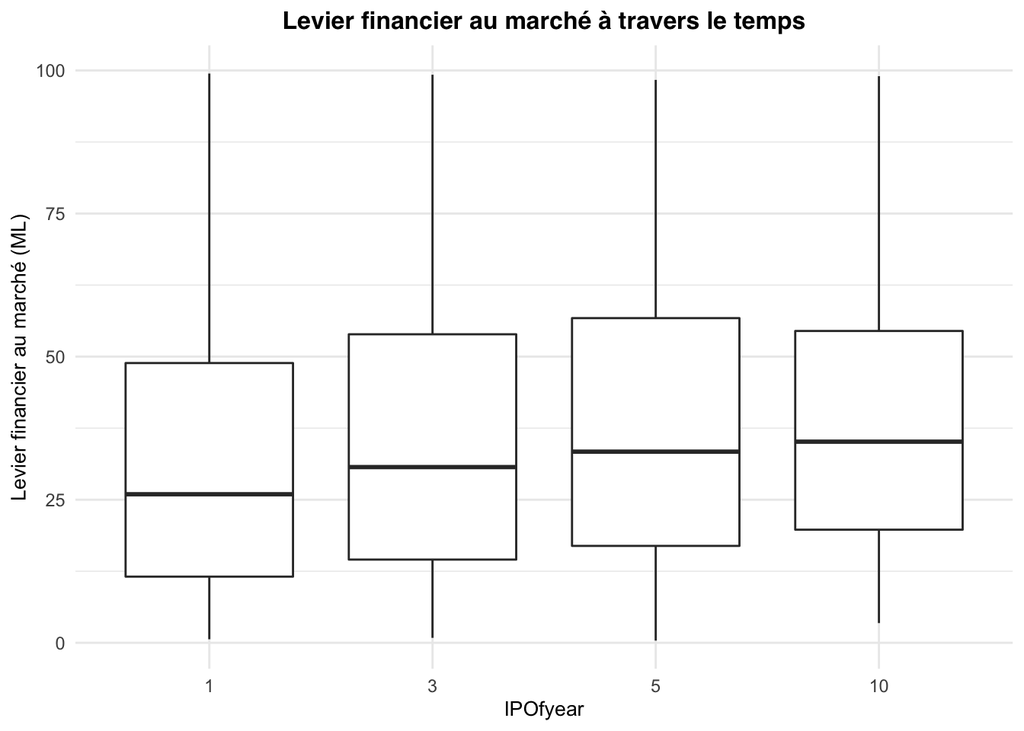

```r
# Version GGPLOT

ggplot(subset(firm_agg1, IPOfyear %in% c(1,3,5,10)), aes(x = as.factor(IPOfyear),
                                                         y = ML,
                                                         group = IPOfyear)) +
  geom_boxplot() +
  labs(x = 'IPOfyear', y = 'Levier financier au marché (ML)') +
  theme_minimal() +
  theme(plot.title = element_text(family = 'Helvetica', face = 'bold', hjust = 0.5, size = 12),
        axis.title.x = element_text(size = 10),
        axis.title.y = element_text(size = 10)) +
  ggtitle('Levier financier au marché à travers le temps')
```

## Tâche 4. (4 points)

Pour les valeurs d’années fiscales `IPOfyear=5,10`, créez des nuages de points (scatterplots) pour visualiser les relations entre les variables `ML`, `lagMBefwa`, `lagMB`, `lagTang`, `lagProf` et `lagSize` et calculez les corrélations entre elles.

Commentez sur les types possibles de relations entre les variables et les possibles corrélations.

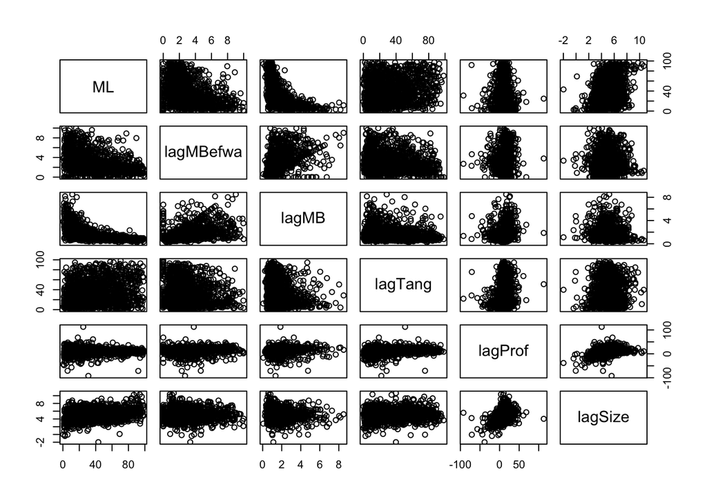

```r
# Nuages de points pour chaque variable

ipo_5 = firm_agg1[firm_agg1$IPOfyear == 5,]
ipo_10 = firm_agg1[firm_agg1$IPOfyear == 10,]
plot(ipo_5[,-1])
```

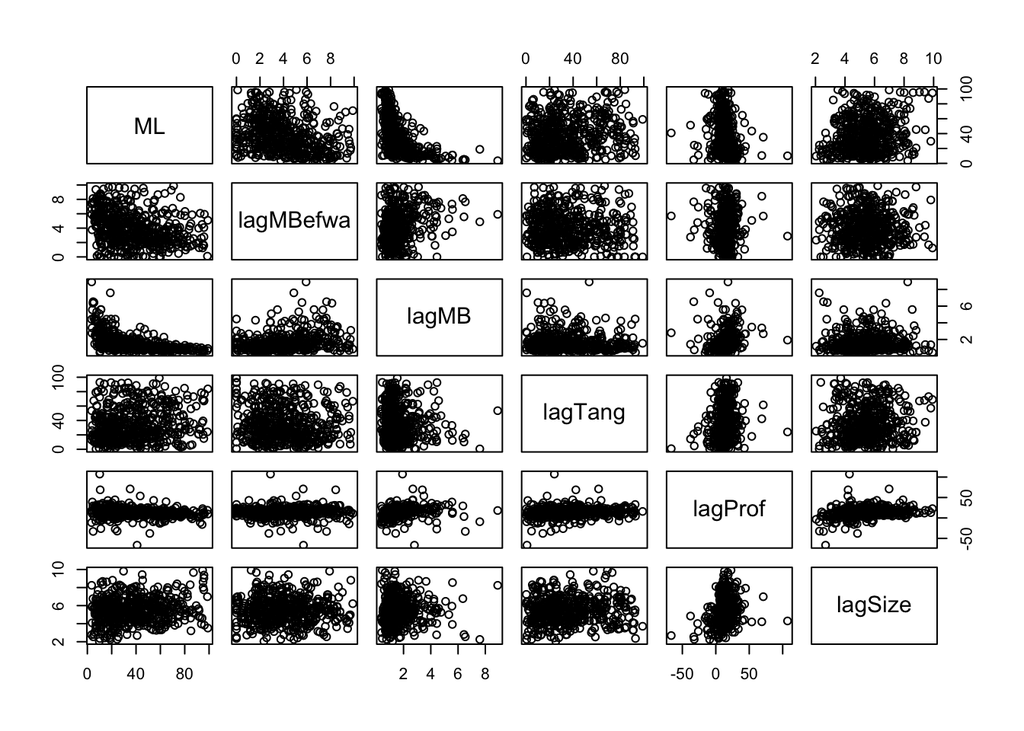

```r
plot(ipo_10[,-1])
```

```r
# Matrices des corrélations

cor(ipo_5[,-1])
```

```
                  ML   lagMBefwa       lagMB    lagTang    lagProf     lagSize
ML         1.0000000 -0.43605016 -0.59438288  0.2367458 -0.1382343  0.28004341
lagMBefwa -0.4360502  1.00000000  0.43584979 -0.1680429  0.1467039 -0.03321178
lagMB     -0.5943829  0.43584979  1.00000000 -0.1435864  0.1803098 -0.05811255
lagTang    0.2367458 -0.16804294 -0.14358645  1.0000000  0.1674263  0.12112246
lagProf   -0.1382343  0.14670393  0.18030975  0.1674263  1.0000000  0.29666848
lagSize    0.2800434 -0.03321178 -0.05811255  0.1211225  0.2966685  1.00000000
```

```r
cor(ipo_10[,-1])
```

```
                  ML   lagMBefwa        lagMB     lagTang     lagProf
ML         1.0000000 -0.28833346 -0.563910138  0.12591461 -0.20837934
lagMBefwa -0.2883335  1.00000000  0.291818467 -0.06088471  0.06323282
lagMB     -0.5639101  0.29181847  1.000000000 -0.06750088  0.18594572
lagTang    0.1259146 -0.06088471 -0.067500878  1.00000000  0.17920796
lagProf   -0.2083793  0.06323282  0.185945717  0.17920796  1.00000000
lagSize    0.1759466  0.01812625  0.005125059  0.08043907  0.26282953
              lagSize
ML        0.175946571
lagMBefwa 0.018126248
lagMB     0.005125059
lagTang   0.080439071
lagProf   0.262829532
lagSize   1.000000000
```

Les graphiques ci-dessus, de même que l’analyse de corrélation montrent que les variables `lagMB` et `lagMBefwa` sont corrélées (négativement) au levier financier au marché `ML`, cependant, l’influence de `lagMBefwa`est plus importante lorsque `IPOfyear = 5`. Ces deux variables explicatives sont légèrement corrélées positivement entre elles. On note également une certaine corrélation entre `ML` et les variables `lagTang`, `lagProf`, `lagSize`, avec un niveau de corrélation néanmoins variable selon l’année fiscale. Ainsi, `lagMBefwa`, `lagTang` et `lagSize`semblent plus significativement corrélées avec `ML`lorsque `IPOfyear = 5`, tandis que `lagProf` semble avoir davantage d’influence sur `ML` lorsque `IPOfyear = 10`.

## Tâche 5. (2 points)

Nous voulons prédire le levier financier au marché à partir des prédicteurs `lagMBefwa`, `lagMB`, `lagTang`, `lagProf` et `lagSize` avec un modèle de régression linéaire multiple, en considerant un sous-ensemble de données défini par la même année fiscale.

Écrivez l’équation du modèle et les hypothèses par rapport aux erreurs.

L’équation du modèle est telle que :

$ML = \beta_0 + \beta_1~lagMBefwa+\beta_2~lagMB+\beta_3~lagTang+\beta_4~lagProf+\beta_5~lagSize + \epsilon_i$

On suppose que :

- Il y a linéarité : $E[Y] = \beta_0 + \beta_1X~~~~ou~~~~y_i = \beta_0+\beta_1x_i+\epsilon_i~~~~avec~~~~E[\epsilon_i]=0 ~~~\forall~~i=1,~...,~n$
- L’homoscédasticité est respectée : $Var(\epsilon_i) = \sigma^2,~\forall~i=1,...,~n$
- Les erreurs sont linéairement indépendantes : $cov(\epsilon_i,\epsilon_j)=0,~\forall~i≠j$
- Les erreurs suivent une loi normale $\epsilon_i\sim N(0,\sigma^2)$

## Tâche 6. (10 points)

Commencez avec la prédiction du levier financier au marché avec le sous-ensemble de données défini par `IPOfyear=5`.

```r
# Modèle non ajusté (facultatif)

lm_multi_ipo5 = lm(ML~.-IPOfyear, data = ipo_5)
summary(lm_multi_ipo5)
```

[output not shown]

### 6.a.

Effectuez une sélection du meilleur sous-ensemble de variables (best subset selection) selon la somme des carrés résiduels, afin de déterminer les meilleurs modèles pour un nombre de prédicteurs variant de 1 à 5.

Quel est le meilleur modèle sélectionné avec le $R^2$ ajusté? Et avec le $C_p$ de Mallow? Et avec le BIC? Choisissez le meilleur des modèles et expliquez votre choix.

```r
library(leaps)
library(car)

# Création du modèle

regsubsets_full = regsubsets(ML ~ . - IPOfyear, data = ipo_5, nvmax = 5)
regsubsets_summary = summary(regsubsets_full)
regsubsets_summary
```

```
Subset selection object
Call: regsubsets.formula(ML ~ . - IPOfyear, data = ipo_5, nvmax = 5)
5 Variables  (and intercept)
          Forced in Forced out
lagMBefwa     FALSE      FALSE
lagMB         FALSE      FALSE
lagTang       FALSE      FALSE
lagProf       FALSE      FALSE
lagSize       FALSE      FALSE
1 subsets of each size up to 5
Selection Algorithm: exhaustive
         lagMBefwa lagMB lagTang lagProf lagSize
1  ( 1 ) " "       "*"   " "     " "     " "
2  ( 1 ) " "       "*"   " "     " "     "*"
3  ( 1 ) "*"       "*"   " "     " "     "*"
4  ( 1 ) "*"       "*"   "*"     " "     "*"
5  ( 1 ) "*"       "*"   "*"     "*"     "*"
```

La fonction `regsubsets()` a créé cinq sous-ensembles. On remarque qu’aucune variable n’a été forcée à l’intérieur du modèle, ou exclue, donc Forced in et Forced out = False.

Par exemple :

- Le premier sous-ensemble est celui qui inclut `lagMB`.
- Le second sous-ensemble est celui qui inclut `lagMB` et `lagSize`.
- Le troisième sous-ensemble est celui qui inclut `lagMBefwa`, `lagMB` et `lagSize`.
- Le quatrième sous-ensemble est celui qui inclut`lagMBefwa`, `lagMB`, `lagTang` et `lagSize`.
- Le dernier inclut `lagMBefwa`, `lagMB`, `lagTang`, `lagProf` et `lagSize`.

Chacun des sous-ensembles peut être évalué selon plusieurs critères. Les graphiques ci-dessous vont nous permettre de déterminer quel modèle semble le plus approprié, en fonction de trois critères : le $R^2$ ajusté, le $C_p$ de Mallows ainsi que le BIC.

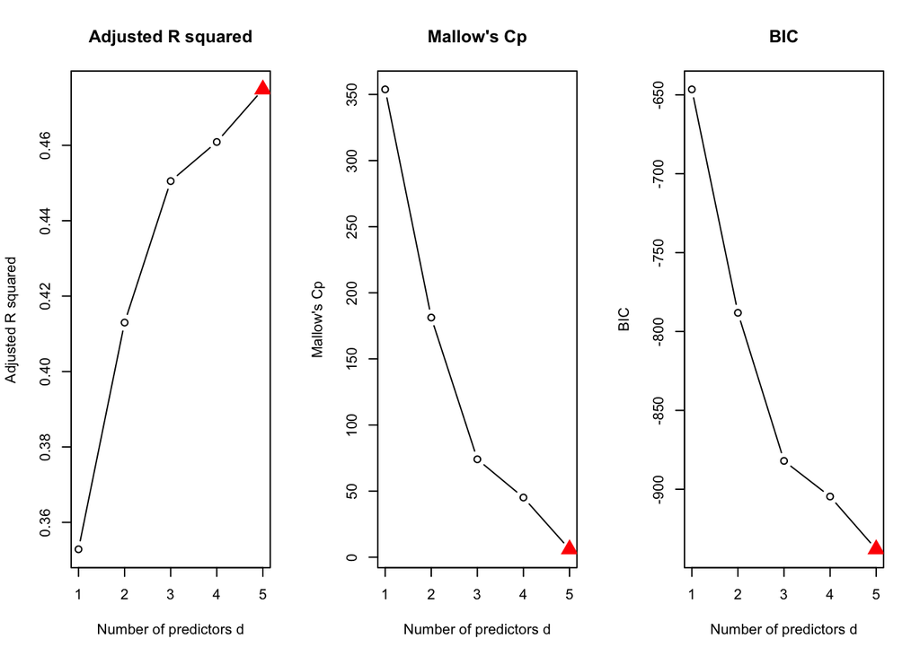

```r
# Ajustement et affichage des graphiques

par( mfrow = c(1, 3) )

plot(regsubsets_summary$adjr2, type = 'b', xlab = 'Number of predictors d', ylab = 'Adjusted R squared', main = 'Adjusted R squared')
best_adjr2 = which.max(regsubsets_summary$adjr2)
best_rsq = which.max(regsubsets_summary$rsq)
points(best_adjr2, regsubsets_summary$adjr2[best_adjr2], col = "red", cex = 2, pch=17)

plot(regsubsets_summary$cp, type = 'b', xlab = 'Number of predictors d', ylab = 'Mallow\'s Cp', main = 'Mallow\'s Cp')
best_cp = which.min(regsubsets_summary$cp)
points(best_cp, regsubsets_summary$cp[best_cp], col = "red", cex = 2, pch=17)

plot(regsubsets_summary$bic, type = 'b', xlab = 'Number of predictors d', ylab = 'BIC', main = 'BIC')
best_bic = which.min(regsubsets_summary$bic)
points(best_bic, regsubsets_summary$bic[best_bic], col = "red", cex = 2, pch=17)
```

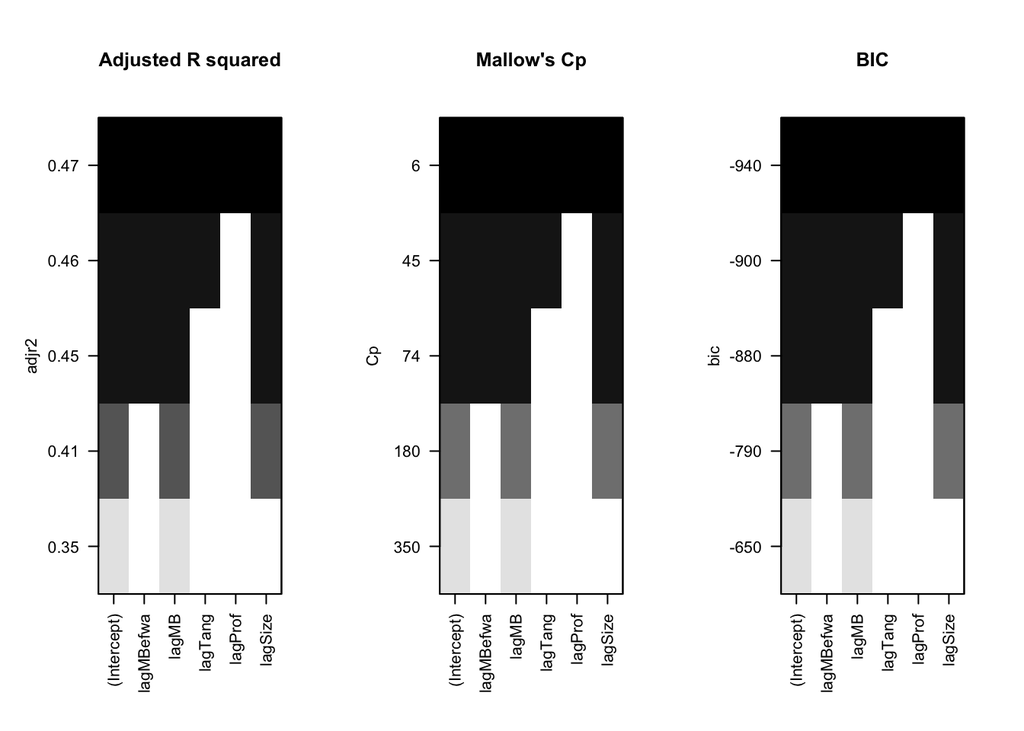

```r
par( mfrow = c(1, 3) )

plot(regsubsets_full, scale = "adjr2", main = 'Adjusted R squared')
plot(regsubsets_full, scale = "Cp", main = 'Mallow\'s Cp')
plot(regsubsets_full, scale = "bic", main = 'BIC')
```

```r
# Coefficients

coef_1 = coef(regsubsets_full, 5)
coef_1
```

[output not shown]

Le modèle optimal dans ce cas semble être celui contenant tous les prédicteurs, en se basant sur les trois critères, qui donnent le même résultat. L’équation est alors la suivante :

*$ML=36.2969447-2.369876lagMBefwa-9.9265125lagMB+0.1400846lagTang-0.2558323lagProf+4.8355222lagSize$

### 6.b.

Ajustez le modèle de régression choisi et commentez les résultats (la significativité globale du modèle, la significativité de chaque terme, la variance expliquée par le modèle).

Vérifiez la validité de la régression en vous basant sur les graphiques des résidus. En particulier, commentez les hypothèses du modèle et la présence de valeurs aberrantes et d’observations influentes.

Enfin, calculez et commentez les facteurs d’inflation de la variance (VIF).

Les coefficients de corrélation entre les variables que nous avons obtenu plus tôt nous indiquent qu’il pourrait y avoir des interactions entre les variables explicatives. Nous décidons de tester cette hypothèse avec un modèle ajusté :

```r
# Modèle ajusté

lm_adj = lm(ML~ lagMBefwa*lagMB+lagTang+lagProf+lagSize, data = ipo_5)
summary(lm_adj)
```

```
Call:
lm(formula = ML ~ lagMBefwa * lagMB + lagTang + lagProf + lagSize,
    data = ipo_5)

Residuals:
    Min      1Q  Median      3Q     Max
-54.568 -12.288  -1.758  11.846  57.340

Coefficients:
                 Estimate Std. Error t value Pr(>|t|)
(Intercept)      47.49712    2.38952  19.877  < 2e-16 ***
lagMBefwa        -5.28128    0.41213 -12.814  < 2e-16 ***
lagMB           -16.11087    0.81785 -19.699  < 2e-16 ***
lagTang           0.12381    0.02061   6.007 2.37e-09 ***
lagProf          -0.23061    0.03896  -5.920 3.99e-09 ***
lagSize           4.63856    0.34327  13.513  < 2e-16 ***
lagMBefwa:lagMB   1.51170    0.16724   9.039  < 2e-16 ***
---
Signif. codes:  0 '***' 0.001 '**' 0.01 '*' 0.05 '.' 0.1 ' ' 1

Residual standard error: 17.72 on 1510 degrees of freedom
Multiple R-squared:  0.5034,    Adjusted R-squared:  0.5015
F-statistic: 255.1 on 6 and 1510 DF,  p-value: < 2.2e-16
```

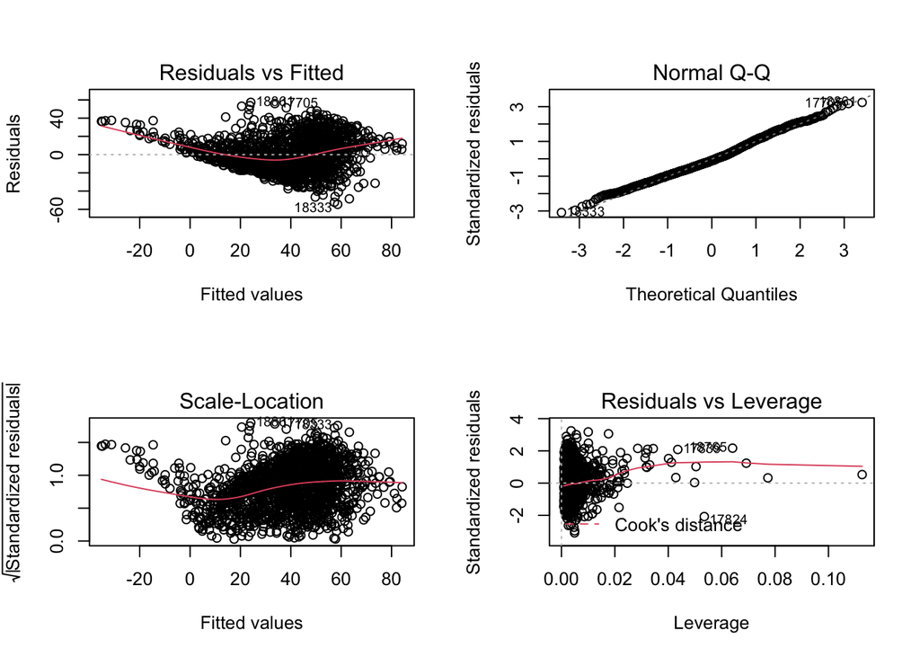

```r
# Graphiques des résidus et VIF

par(mfrow = c(2,2))
plot(lm_adj)
```

```r
vif(lm_adj)
```

```
      lagMBefwa           lagMB         lagTang         lagProf         lagSize
       3.253924        4.266571        1.094503        1.200632        1.121043
lagMBefwa:lagMB
       7.921994
```

Le modèle est significatif, puisque la $p-value$ du test F est inférieure à $2.2\times10^{-16}$. Le modèle est moyennement performant, puisqu’il n’explique que 50% de la variance du levier financier au marché. Les prédicteurs sont significatifs, de même que l’interaction entre `lagMBefwa`et `lagMB` : la valeur du test t pour les coefficients $\beta_j$ est très faible.

L’analyse des résidus montre que l’homoscédasticité ne semble pas vérifiée, car dans le premier graphique, la variabilité augmente avec l’augmentation des valeurs prédites. L’indépendance ne semble pas non plus vérifiée, car lorsque les valeurs prédites augmentent, les résidus diminuent, avant d’augmenter à nouveau. La normalité des résidus semble bonne et, en dehors de quelques valeurs éloignées, aucune ne dépasse la distance de Cook, toutes les valeurs extrêmes sont en dessous de 0.5.

Enfin, le $VIF$ de chacun des coefficients est inférieur à 10, ce qui démontre que la colinéarité des prédicteurs n’est pas forte. Seul celui de la variable représentant l’interaction entre `lagMBefwa` et `lagMB` est plus élevé, mais toujours inférieur à 10.

## Tâche 7. (10 points)

Répétez l’analyse faite au point 6 avec l’année `IPOfyear=10`.

```r
# Modèle non ajusté (facultatif)

lm_multi_ipo10 = lm(ML~.-IPOfyear, data = ipo_10)
summary(lm_multi_ipo10)
```

```
Call:
lm(formula = ML ~ . - IPOfyear, data = ipo_10)

Residuals:
    Min      1Q  Median      3Q     Max
-45.506 -12.641  -2.846  10.910  55.791

Coefficients:
             Estimate Std. Error t value Pr(>|t|)
(Intercept)  41.81521    3.74546  11.164  < 2e-16 ***
lagMBefwa    -1.35097    0.36484  -3.703 0.000236 ***
lagMB       -10.35823    0.78209 -13.244  < 2e-16 ***
lagTang       0.10036    0.03503   2.865 0.004339 **
lagProf      -0.35653    0.07057  -5.052 6.10e-07 ***
lagSize       3.66074    0.58816   6.224 1.01e-09 ***
---
Signif. codes:  0 '***' 0.001 '**' 0.01 '*' 0.05 '.' 0.1 ' ' 1

Residual standard error: 17.97 on 508 degrees of freedom
Multiple R-squared:  0.4022,    Adjusted R-squared:  0.3963
F-statistic: 68.36 on 5 and 508 DF,  p-value: < 2.2e-16
```

```r
# Création des sous ensembles

regsubsets_full_2 = regsubsets(ML ~ . - IPOfyear, data = ipo_10, nvmax = 5)
regsubsets_summary_2 = summary(regsubsets_full_2)
regsubsets_summary_2
```

```
Subset selection object
Call: regsubsets.formula(ML ~ . - IPOfyear, data = ipo_10, nvmax = 5)
5 Variables  (and intercept)
          Forced in Forced out
lagMBefwa     FALSE      FALSE
lagMB         FALSE      FALSE
lagTang       FALSE      FALSE
lagProf       FALSE      FALSE
lagSize       FALSE      FALSE
1 subsets of each size up to 5
Selection Algorithm: exhaustive
         lagMBefwa lagMB lagTang lagProf lagSize
1  ( 1 ) " "       "*"   " "     " "     " "
2  ( 1 ) " "       "*"   " "     " "     "*"
3  ( 1 ) " "       "*"   " "     "*"     "*"
4  ( 1 ) "*"       "*"   " "     "*"     "*"
5  ( 1 ) "*"       "*"   "*"     "*"     "*"
```

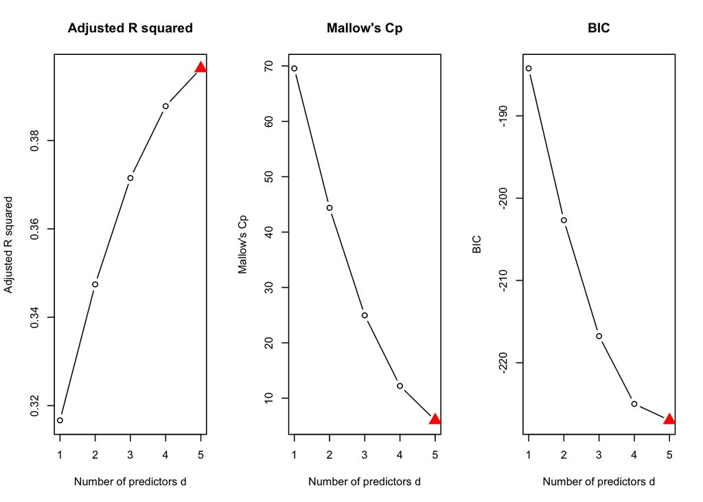

```r
par( mfrow = c(1, 3) )

plot(regsubsets_summary_2$adjr2, type = 'b', xlab = 'Number of predictors d', ylab = 'Adjusted R squared', main = 'Adjusted R squared')
best_adjr2_2 = which.max(regsubsets_summary_2$adjr2)
best_rsq_2 = which.max(regsubsets_summary_2$rsq)
points(best_adjr2_2, regsubsets_summary_2$adjr2[best_adjr2_2], col = "red", cex = 2, pch=17)

plot(regsubsets_summary_2$cp, type = 'b', xlab = 'Number of predictors d', ylab = 'Mallow\'s Cp', main = 'Mallow\'s Cp')
best_cp_2 = which.min(regsubsets_summary_2$cp)
points(best_cp_2, regsubsets_summary_2$cp[best_cp_2], col = "red", cex = 2, pch=17)

plot(regsubsets_summary_2$bic, type = 'b', xlab = 'Number of predictors d', ylab = 'BIC', main = 'BIC')
best_bic_2 = which.min(regsubsets_summary_2$bic)
points(best_bic_2, regsubsets_summary_2$bic[best_bic_2], col = "red", cex = 2, pch=17)
```

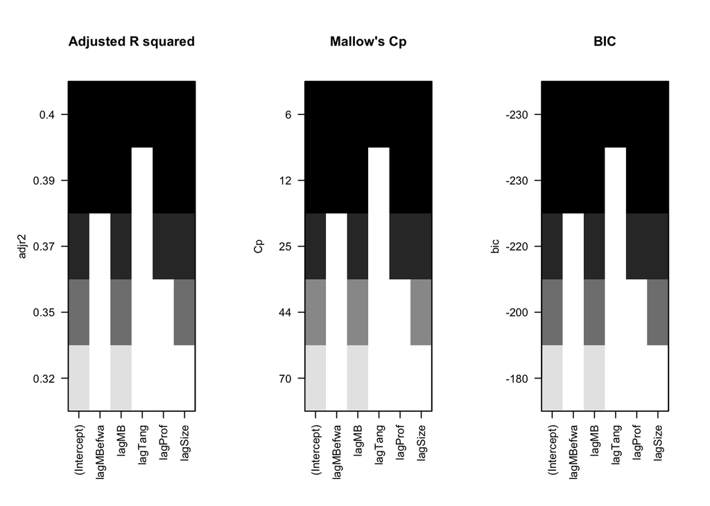

```r
par( mfrow = c(1, 3) )

plot(regsubsets_full_2, scale = "adjr2", main = 'Adjusted R squared')
plot(regsubsets_full_2, scale = "Cp", main = 'Mallow\'s Cp')
plot(regsubsets_full_2, scale = "bic", main = 'BIC')
```

```r
coef_2 = coef(regsubsets_full_2, 5)
```

Si on se fie aux trois critères donnant le même meilleur modèle, il semblerait que le meilleur modèle soit celui comportant toutes les variables. Les coefficients de corrélation entre les variables obtenus plus tôt nous indiquent une fois de plus qu’il pourrait y avoir des interactions possibles entre les variables explicatives. Nous décidons de tester cette hypothèse avec un nouveau modèle. Nous avons testé plusieurs modèles, en regardant à chaque fois la significativité de chaque variable et des variables d’interaction. Lorsque celles-ci n’étaient pas significatives, nous les avons retirées. Ainsi, le meilleur modèle obtenu est celui-ci :

```r
# Modèle ajusté

lm_adj_2 = lm(ML~ lagMBefwa+lagMB+lagTang+lagProf+lagSize+lagMBefwa:lagSize, data = ipo_10)
summary(lm_adj_2)
```

```
Call:
lm(formula = ML ~ lagMBefwa + lagMB + lagTang + lagProf + lagSize +
    lagMBefwa:lagSize, data = ipo_10)

Residuals:
    Min      1Q  Median      3Q     Max
-49.808 -12.029  -2.411  10.950  54.321

Coefficients:
                   Estimate Std. Error t value Pr(>|t|)
(Intercept)        25.25880    6.54216   3.861 0.000128 ***
lagMBefwa           2.78524    1.39318   1.999 0.046121 *
lagMB             -10.21574    0.77705 -13.147  < 2e-16 ***
lagTang             0.09833    0.03474   2.830 0.004836 **
lagProf            -0.34408    0.07011  -4.908 1.24e-06 ***
lagSize             6.68273    1.14301   5.847 8.99e-09 ***
lagMBefwa:lagSize  -0.76792    0.24978  -3.074 0.002223 **
---
Signif. codes:  0 '***' 0.001 '**' 0.01 '*' 0.05 '.' 0.1 ' ' 1

Residual standard error: 17.83 on 507 degrees of freedom
Multiple R-squared:  0.4131,    Adjusted R-squared:  0.4062
F-statistic: 59.49 on 6 and 507 DF,  p-value: < 2.2e-16
```

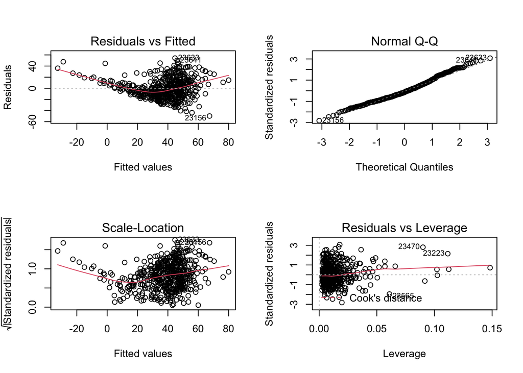

```r
# Grpahiques des résidus et VIF

par(mfrow = c(2,2))
plot(lm_adj_2)
```

```r
vif(lm_adj_2)
```

```
        lagMBefwa             lagMB           lagTang           lagProf
        16.244597          1.142889          1.048152          1.156926
          lagSize lagMBefwa:lagSize
         4.138259         19.703074
```

Le modèle est significatif, puisque la $p-value$ du test F est inférieure à $2.2\times10^{-16}$. Le modèle est moins performant, puisqu’il n’explique que 40% de la variance du levier financier au marché. Les prédicteurs sont plus ou moins significatifs et la valeur du test t pour chacun des coefficients $\beta_j$ n’est pas toujours inférieure à $2.2\times10^{-16}$, mais demeure faible. L’analyse des résidus montre que l’homoscédasticité ne semble pas vérifiée, les valeurs des résidus se dispersent lorsque les valeurs prédites augmentent. La normalité des résidus semble respectée et, en dehors de quelques valeurs éloignées, aucune ne dépasse la distance de Cook.

On remarque une colinéarité forte avec les variables `lagMBefwa` et la variable d’interaction `lagMBefwa:lagSize`, avec un VIF > 10. Les autres valeurs sont normales (< 10), donc pas de colinéarité. Le modèle ajuste semble mieux expliquer le levier financier au marché que le modèle de base, néanmoins, la variable d’interaction semble avoir introduit de la colinéarité dans le modèle, comme en témoigne les valeurs du VIF.

## Tâche 8. (6 points)

Ajustez deux modèles de régression pénalisée lasso pour prédire le levier financier au marché à partir des prédicteurs `lagMBefwa`, `lagMB`, `lagTang`, `lagProf` et `lagSize`, un pour le sous-ensemble de données défini par `IPOfyear=5` et un pour `IPOfyear=10`. Créez les graphiques lasso trace (valeurs des coefficients en fonction du paramètre $\lambda$) et utilisez la 10-validation croisée pour choisir la valeur optimale pour le paramètre de réglage $\lambda$ (utilisez `set.seed(2021)`) pour chaque modèle. Commentez tous les résultats.

**Pour `IPOfyear=5` :**

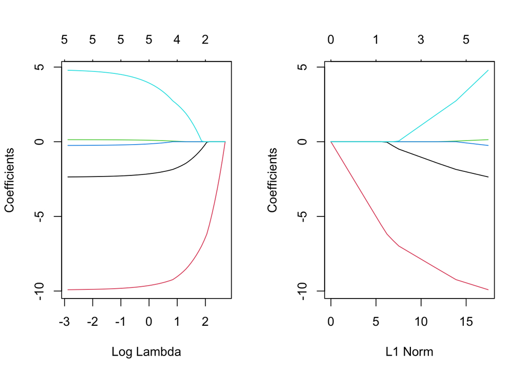

```r
library(glmnet)

x = model.matrix(ML ~ lagMBefwa + lagMB + lagTang + lagProf + lagSize, data = ipo_5)[,-1]
y = ipo_5$ML

# Modèle LASSO

lasso_model = glmnet(x, y, alpha = 1)
par(mfrow = c(1,2))
plot(lasso_model, xvar = 'lambda')
plot(lasso_model, xvar = 'norm')
```

**Pour `IPOfyear = 10` :**

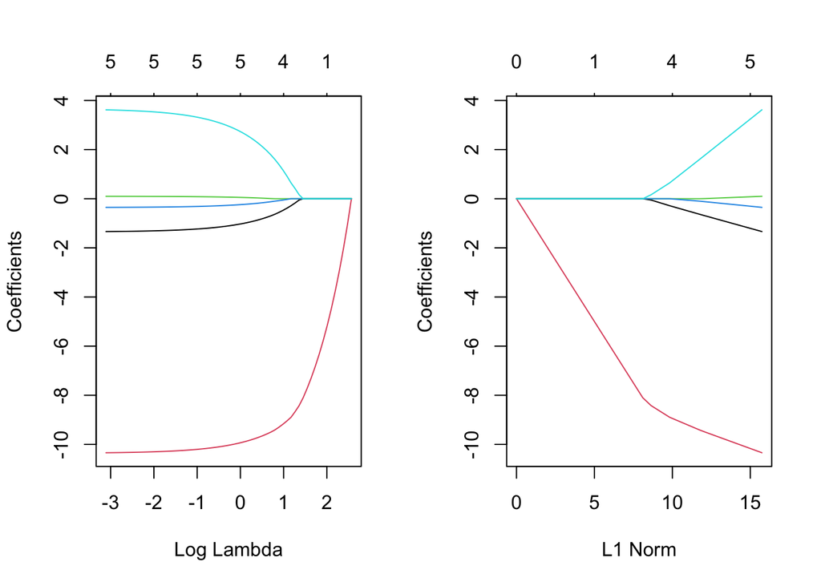

```r
x_1 = model.matrix(ML ~ lagMBefwa + lagMB + lagTang + lagProf + lagSize, data = ipo_10)[,-1]
y_1 = ipo_10$ML

lasso_model_1 = glmnet(x_1, y_1, alpha = 1)
par(mfrow = c(1,2))
plot(lasso_model_1, xvar = 'lambda')
plot(lasso_model_1, xvar = 'norm')
```

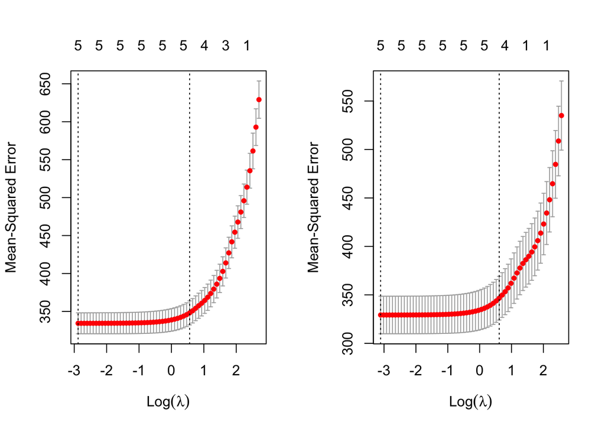

```r
set.seed(2021)

par(mfrow = c(1,2))
# Année fiscale 5

cv_lasso = cv.glmnet(x, y, alpha = 1, nfolds = 10)
plot(cv_lasso)

# Année fiscale 10

cv_lasso_1 = cv.glmnet(x_1, y_1, alpha = 1, nfolds = 10)
plot(cv_lasso_1)
```

**Analyse des lasso traces et des MSE en fonction de lambda, pour les deux années fiscales :**

*Pour `IPOfyear = 5`*, deux coefficients semblent stables et proches de zéro lorsque la valeur de lambda est faible, ce qui correspond au modèle à cinq variables. Lorsque lambda augmente, les valeurs des coefficients viennent peu à peu s’annuler au fur et à mesure que la pénalisation du modèle augmente, jusqu’à atteindre zéro. Si on regarde le graphique de la MSE en fonction de $Log(\lambda)$, à gauche, nous observons qu’effectivement, lorsque cette valeur augmente, l’erreur quadratique moyenne augmente très fortement, ce qui n’est pas un bon signe.

Nous cherchons alors à minimiser la valeur de lambda et trouver sa valeur la plus élevée telle que la MSE est contenu dans un intervalle d’un écart type du lambda minimum (la ligne pointillée du graphique). Pour la sixième année fiscale, on obtient $\lambda=$ **1.755**. La valeur lambda qui minimise la MSE est **0.056** : cette valeur correspond à notre modèle à cinq variables.

Pour conclure, l’analyse des graphiques ci-dessus nous permet de conclure que les meilleurs modèles dans les deux années sont ceux qui contiennent cinq variables explicatives à chaque fois.

## Tâche 9. (4 points)

Organisez les résultats des régressions sélectionnées aux points 6 et 7 dans un tableau affichant les coefficients des termes de régression, les $R^2$ et la taille des sous-échantillons. Organisez les résultats des modèles lasso obtenus au point 8 (utilisez le plus grand `lambda` tel que le MSE est contenu dans un intervalle d’un écart type du minimum, c’est-à-dire `lambda.1se`) dans un tableau affichant les coefficients des termes de régression.

```r
tab_1 = tibble(Observations = c('lagMBefwa', 'lagMB', 'lagTang', 'lagProf', 'lagSize', 'R-squared', 'Adjusted R-squared', 'Taille des sous-échantillons'),
               'IPOfyear = 5' = as.character(c(coef_1[2], coef_1[3], coef_1[4], coef_1[5], coef_1[6], regsubsets_summary$rsq[best_rsq], regsubsets_summary$adjr2[best_adjr2], nrow(ipo_5))),
               'IPOfyear = 10' = as.character(c(coef_2[2], coef_2[3], coef_2[4], coef_2[5], coef_2[6], regsubsets_summary_2$rsq[best_rsq_2], regsubsets_summary_2$adjr2[best_adjr2_2], nrow(ipo_10))))

tab_2 = tibble(Observations = c('lagMBefwa', 'lagMB', 'lagTang', 'lagProf', 'lagSize', 'lambda.1se'),
               'IPOfyear = 5' = as.character(c(coef(cv_lasso, s = 'lambda.1se')[2], coef(cv_lasso, s = 'lambda.1se')[3], coef(cv_lasso, s = 'lambda.1se')[4], coef(cv_lasso, s = 'lambda.1se')[5], coef(cv_lasso, s = 'lambda.1se')[6], cv_lasso$lambda.1se)),
               'IPOfyear = 10' = c(coef(cv_lasso_1, s = 'lambda.1se')[2], coef(cv_lasso_1, s = 'lambda.1se')[3], coef(cv_lasso_1, s = 'lambda.1se')[4], coef(cv_lasso_1, s = 'lambda.1se')[5], coef(cv_lasso_1, s = 'lambda.1se')[6], cv_lasso_1$lambda.1se))
```

| Observations | IPOfyear = 5 | IPOfyear = 10 |
| --- | --- | --- |
| lagMBefwa | -2.36987603603886 | -1.35096995155122 |
| lagMB | -9.92651252793841 | -10.3582332896594 |
| lagTang | 0.140084603223172 | 0.100360066354139 |
| lagProf | -0.255832271728414 | -0.356531949385393 |
| lagSize | 4.83552224754867 | 3.66074213659327 |
| R-squared | 0.476559653134999 | 0.402199437849761 |
| Adjusted R-squared | 0.474827554038821 | 0.39631557404907 |
| Taille des sous-échantillons | 1517 | 514 |

| Observations | IPOfyear = 5 | IPOfyear = 10 |
| --- | --- | --- |
| lagMBefwa | -1.98190189999018 | -0.7534345 |
| lagMB | -9.40360804201764 | -9.5742324 |
| lagTang | 0.0671763483770451 | 0.0149740 |
| lagProf | -0.0624196451135944 | -0.1419704 |
| lagSize | 3.25022747592098 | 1.9475184 |
| lambda.1se | 1.75450083777298 | 1.8472021 |

### 9.a.

Commentez sur la taille des sous-échantillons, les coefficients de régression et le comportement du $R^2$ dans les deux modèles de régression linéaire multiple. Comparez les coefficients avec ceux des modèles lasso.

### 9.b.

Comparez les signes des coefficients de `lagMBefwa` et `lagMB`. L’introduction de la variable `lagMBefwa` par Baker & Wurgler (2002) a été utile pour l’analyse? Quels sont les effets d’une augmentation d’une unité de `lagMBefwa` dans les modèles considérés, en conservant les autres facteurs constants?

Les deux variables possèdent le même signe. Il y a une relation négative entre ces dernières et le levier financier au marché, toutes choses étant égales par ailleurs. Ainsi, une augmentation seule d’une unité de `lagMBefwa` provoque une diminution de **-2.3699** unité de `ML` lors de la sixième année fiscale, et de **-1.351** lors de la onzième année fiscale.

Pour le modèle lasso, une augmentation d’une unité de `lagMBefwa` entraine une variation à la baisse de **-1.9819** de `ML` pour l’année fiscale six et de **-0.7534** de ML pour l’année fiscale 11. Nous pouvons aussi confirmer, d’après l’analyse des coefficients, qu’il ne semble pas y avoir de colinéarité entre nos variables car les signes des coefficients sont restés identiques si on les compare à ce qu’on avait dans la matrice de corrélation des variables.

Enfin, l’introduction de la variable lagMBefwaw est utile dans l’analyse car elle apparait significative dans tous les différents modèles et pour toutes les périodes considérées. Ainsi, on peut lire dans [Baker & Wurgler (2002)](https://doi.org/10.1111/1540-6261.00414) que : *“The significance of the MBefwa variable then reflects the fact that leverage depends on the path of market valuations between the IPO and today.”*